# Práctica 2: Limpieza y validación de los datos

José Luis Rodríguez Andreu

18/5/2021

# 1. Introducción

El objetivo de esta práctica es la realización de un proceso de limpieza de un conjunto de datos. Para ello, se ha escogido el conjunto de datos Pima Indians Diabetes de la plataforma Kaggle (https://www.kaggle.com/uciml/pima-indians-diabetes-database).

Este conjunto de datos contiene información médica sobre mujeres relacionada con el diagnóstico de la diabetes. Consta de 768 observaciones con las siguientes variables:

- `Pregnancies`: Número de embarazos que ha tenido la paciente.
- `Glucose`: Concentración de glucosa en plasma a las 2 horas en una prueba oral de tolerancia a la glucosa.
- `BloodPressure`: Presión arterial diastólica (mm Hg)
- `SkinThickness`: Espesor del pliegue cutáneo del tríceps (mm)
- `Insulin`: Insulina en suero a las 2 horas (mu U/ml)
- `BMI`: Índice de masa corporal
- `DiabetesPedigreeFunction`: Función de pedigrí de la diabetes
- `Age`: Edad
- `Outcome`: Variable indicadora de que si la paciente padece o no de diabetes. La clase 1 indica que padece diabetes. 268 de 768 registros se encuentran etiquetados con 1.

# 2. Importancia y objetivo del análisis

Este conjunto de datos procede del Instituto Nacional de Diabetes y Enfermedades Digestivas y Renales de EEUU. El objetivo del conjunto de datos es realizar un diagnóstico predictivo sobre si un paciente tiene o no diabetes, basándose en determinadas mediciones de índole médica incluidas en el conjunto de datos. En este conjunto de datos, todos los pacientes registrados son mujeres de al menos 21 años de edad de origen “indio Pima”. Por lo tanto, el objetivo principal de este proyecto es el de definir unas pautas de limpieza y preprocesado de datos para poder realizar un diagnóstico automático basado en técnicas de aprendizaje automático lo mas preciso posible.

La importancia del diseño de modelos de machine learning capaces de realizar diagnósticos médicos con precisión ayuda a los profesionales de la medicina a la hora de atender pacientes, y desemboca en una mejora del propio sistema sanitario, ya que este tipo de diagnósticos permiten ahorrar costes en análisis y tiempo de los profesionales, permitiendo de esta manera la reinversión de esos gastos sanitarios en promover una atención médica de calidad, además de facilitar el trabajo al personal sanitario que frecuentemente, y mas en época de pandemia, se encuentra saturado por una alta carga de trabajo.

# 3. Integración y selección de los datos de interés a analizar

En este caso, vamos a trabajar con todas las variables descritas en el dataset, ya que todas tienen potencial para resultar útiles en la búsqueda de patrones que permitan la identificación automática de la diabetes.

# 4. Limpieza de los datos

Importamos el fichero `diabetes.csv`. Observamos que todas las variables son de tipo entero o numérico. La variable `Outcome` aunque toma valores numéricos de 0 y 1, es en reailidad una variable categórica binaria.

```r
df = read.csv("../csv/diabetes.csv", encoding = 'UTF-8')
str(df)
```

```
## 'data.frame':    768 obs. of  9 variables:
##  $ Pregnancies             : int  6 1 8 1 0 5 3 10 2 8 ...
##  $ Glucose                 : int  148 85 183 89 137 116 78 115 197 125 ...
##  $ BloodPressure           : int  72 66 64 66 40 74 50 0 70 96 ...
##  $ SkinThickness           : int  35 29 0 23 35 0 32 0 45 0 ...
##  $ Insulin                 : int  0 0 0 94 168 0 88 0 543 0 ...
##  $ BMI                     : num  33.6 26.6 23.3 28.1 43.1 25.6 31 35.3 30.5 0 ...
##  $ DiabetesPedigreeFunction: num  0.627 0.351 0.672 0.167 2.288 ...
##  $ Age                     : int  50 31 32 21 33 30 26 29 53 54 ...
##  $ Outcome                 : int  1 0 1 0 1 0 1 0 1 1 ...
```

```r
head(df)
```

```
##   Pregnancies Glucose BloodPressure SkinThickness Insulin  BMI
## 1           6     148            72            35       0 33.6
## 2           1      85            66            29       0 26.6
## 3           8     183            64             0       0 23.3
## 4           1      89            66            23      94 28.1
## 5           0     137            40            35     168 43.1
## 6           5     116            74             0       0 25.6
##   DiabetesPedigreeFunction Age Outcome
## 1                    0.627  50       1
## 2                    0.351  31       0
## 3                    0.672  32       1
## 4                    0.167  21       0
## 5                    2.288  33       1
## 6                    0.201  30       0
```

Realizamos un análisis estadístico inicial para conocer la distribución de los datos:

```r
summary(df)
```

```
##   Pregnancies        Glucose      BloodPressure    SkinThickness
##  Min.   : 0.000   Min.   :  0.0   Min.   :  0.00   Min.   : 0.00
##  1st Qu.: 1.000   1st Qu.: 99.0   1st Qu.: 62.00   1st Qu.: 0.00
##  Median : 3.000   Median :117.0   Median : 72.00   Median :23.00
##  Mean   : 3.845   Mean   :120.9   Mean   : 69.11   Mean   :20.54
##  3rd Qu.: 6.000   3rd Qu.:140.2   3rd Qu.: 80.00   3rd Qu.:32.00
##  Max.   :17.000   Max.   :199.0   Max.   :122.00   Max.   :99.00
##     Insulin           BMI        DiabetesPedigreeFunction      Age
##  Min.   :  0.0   Min.   : 0.00   Min.   :0.0780           Min.   :21.00
##  1st Qu.:  0.0   1st Qu.:27.30   1st Qu.:0.2437           1st Qu.:24.00
##  Median : 30.5   Median :32.00   Median :0.3725           Median :29.00
##  Mean   : 79.8   Mean   :31.99   Mean   :0.4719           Mean   :33.24
##  3rd Qu.:127.2   3rd Qu.:36.60   3rd Qu.:0.6262           3rd Qu.:41.00
##  Max.   :846.0   Max.   :67.10   Max.   :2.4200           Max.   :81.00
##     Outcome
##  Min.   :0.000
##  1st Qu.:0.000
##  Median :0.000
##  Mean   :0.349
##  3rd Qu.:1.000
##  Max.   :1.000
```

## 4.1. Tratamiento de valores perdidos

Comprobamos que en este caso el conjunto de datos no presenta registros con valores nulos en alguna de sus variables. En el caso de que existiesen, se plantearía la posibilidad de realizar una imputación empleando alguna técnica de inferencia de ese valor a partir del resto de variables, ya que el conjunto de datos no es excesivamente grande y nos interesa mantener un buen número de registros.

```r
sapply(df, function(x) sum(is.na(x)))
```

```
##              Pregnancies                  Glucose            BloodPressure
##                        0                        0                        0
##            SkinThickness                  Insulin                      BMI
##                        0                        0                        0
## DiabetesPedigreeFunction                      Age                  Outcome
##                        0                        0                        0
```

## 4.2. Identificación y tratamiento de valores extremos

aplicamos un diagrama de cajas para observar si se observan valores anómalos u outliers:

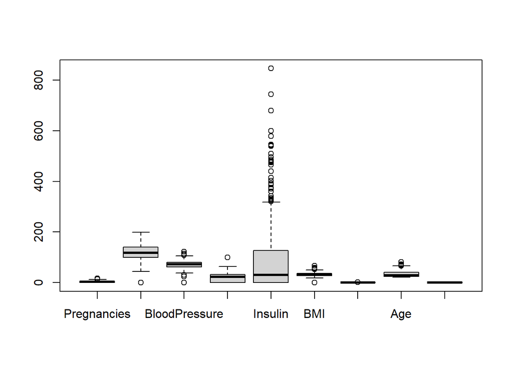

```r
boxplot(df)
```

Observamos que la mayoría de las variables tienen outliers, pero se encuentran en una posición cercana al cuerpo de la distribución. dado que no tenemos ningún tipo de restricción respecto al intervalo donde deben moverse los datos, los dejamos tal y como están. La única que presenta mas outliers visibles es Insulin. Estudiamos su distribución:

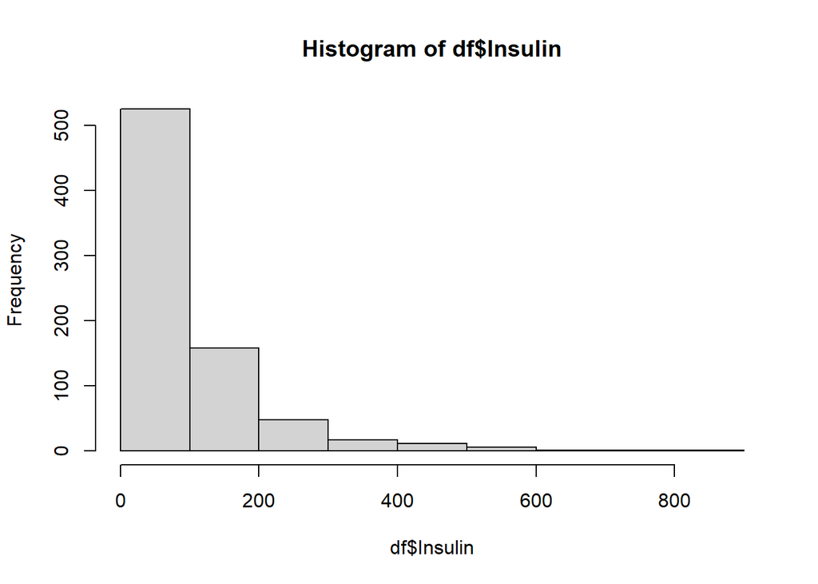

```r
hist(df$Insulin)
```

Observamos que es una distribución descendente, la cual mantiene la gran mayoría de los registros en el intervalo de entre 0 y 200, pero se observa que la distribución cae de manera homogenea. Esto nos dice que esta variable sigue una distribución distinta a la normal, y esa es la causa de que el boxplot detecte tantos outliers. Dado que estos valores extremos no son casos puntuales, decidimos dejarlos como están, ya que pueden ser datos anómalos pero correctos.